# Markdown_Netflix_b

Problématique : Est ce que le nombre de vues a une influence sur les notes ?

Avant tout installer le package/librairie : rmarkdown, shiny, shinydashboard, ggplot2, boot, cramer

## Présentation du jeu de données.

je vais donc avant tous vous présentez mon jeu de données.

Notre jeu de données est basé sur des données Netflix. Nous avons décomposé ces données en trois tables différentes.

La table Films où on retrouve toutes les infos sur les films du catalogue Netflix comme : /title : titre des films /film_id : l’id de chaque film /type : si c’est un film ou une série (TV show) on retrouve dans cet attribut deux valeurs faussées : une vide et une noté “William Wyler”. /director : le nom des directeurs des films /cast : le casting du film /country : le pays d’où viens le film /date_added : la date ou le films a été ajouté au catalogue Netflix /release_years : l’année de sortie du film /duration : la durée du film/ nombre de saison pour les séries -marks : la note du film /view : le nombre de vu de chaque film /Deux clés étrangères l’id rating ainsi que l’id de listed in.

La table Rating, qui est composée de deux attributs: Les différents types de rating ainsi que leur id correspondant. Les rating sont donc le type d’interdiction selon les films. Nous y retrouvons les célèbres PG/TV-Age comme par exemple PG-13 qui veut donc dire interdit au moins de 13 ans. Mais il existe d’autres rating moins connu comme : /TV-MA (contenu destiné aux publics matures);TV-Y (un contenu qui convient aux enfants d’âge préscolaire) /TV-Y7 (un contenu pour les enfants âgés de 7 ans et plus.) /R (constitue un avertissement fort envers les parents d’enquêter plus en profondeur sur le contenu d’un film avant d’emmener leurs enfants les voir.) /G (Un film classé G, signifie qu’il est pour tous les âges.) /NC-17 (la note la plus élevée du système de classification des films, conseillé fortement pour les adultes) puis nous y retrouvons des rating qui n’ont pas de sens comme des durées ou encore UR qui est un rating d’URL et non de film nous avons tout de même décidé de ne pas modifier le fichier et donc de garder ces valeurs incohérentes.

Et enfin la table liste ou on y retrouve : les différents thèmes ansi que leurs id correspondant.

Pour vous expliquer les liens de nos tables voici un mcd de notre BDD: (modifier le lien avec l’emplacement du mcd)

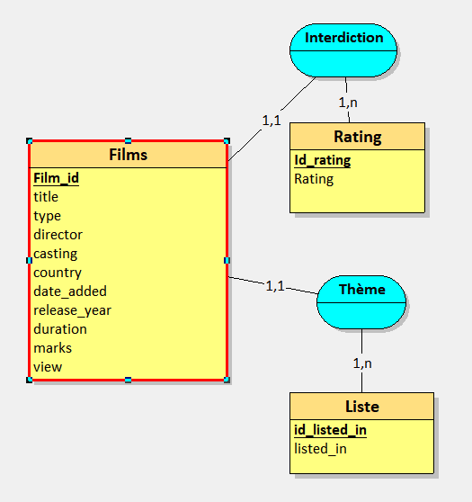

```r
knitr::include_graphics("C:/Users/Lucas/OneDrive/Bureau/Projet Shiny/mcd netflix.PNG")
```

On peut donc bien mieux comprendre comment fonctionne notre MCD avec une table assez imposante “Films” qui est donc liée à la table rating et liste. On comprend donc que leur lien est fait grâce à leur id:

un film n’a qu’un seul rating et un rating peut avoir plusieur films un film n’a qu’un thème alors qu’un thème peut avoir plusieur films

```r
films <- read.csv(file = "Films.csv", sep = ";")
summary(films)
```

```
##     title             film_id              type            id_rating
##  Length:8809        Length:8809        Length:8809        Length:8809
##  Class :character   Class :character   Class :character   Class :character
##  Mode  :character   Mode  :character   Mode  :character   Mode  :character
##
##
##
##    director             cast             country           date_added
##  Length:8809        Length:8809        Length:8809        Length:8809
##  Class :character   Class :character   Class :character   Class :character
##  Mode  :character   Mode  :character   Mode  :character   Mode  :character
##
##
##
##  release_year         duration          listed_in         id_listed_in
##  Length:8809        Length:8809        Length:8809        Length:8809
##  Class :character   Class :character   Class :character   Class :character
##  Mode  :character   Mode  :character   Mode  :character   Mode  :character
##
##
##
##      marks            view
##  Min.   :0.000   Min.   :    72
##  1st Qu.:1.000   1st Qu.:248750
##  Median :3.000   Median :493855
##  Mean   :2.499   Mean   :496833
##  3rd Qu.:4.000   3rd Qu.:744918
##  Max.   :5.000   Max.   :999907
```

```r
dim(x = films)
```

```
## [1] 8809   14
```

```r
colnames(x = films)
```

```
##  [1] "title"        "film_id"      "type"         "id_rating"    "director"
##  [6] "cast"         "country"      "date_added"   "release_year" "duration"
## [11] "listed_in"    "id_listed_in" "marks"        "view"
```

On retrouve ici toutes les informations concernant la table film. Je vais me concentrer sur les attributs view et marks car ils sont directement liés à la problématique. Donc on comprend bien que ces deux attributs sont des entier “int”. On retrouve d’ailleurs de nombreuses analyses faite sur leur chiffre mais nous en parlerons un peu plus tard.

```r
rating <- read.csv(file = "Rating.csv", sep = ";")
summary(rating)
```

```
##     rating            id_rating
##  Length:18          Min.   : 1.00
##  Class :character   1st Qu.: 5.25
##  Mode  :character   Median : 9.50
##                     Mean   : 9.50
##                     3rd Qu.:13.75
##                     Max.   :18.00
```

```r
dim(x = rating)
```

```
## [1] 18  2
```

```r
colnames(x = rating)
```

```
## [1] "rating"    "id_rating"
```

```r
rating$id_rating <- factor(rating$id_rating)
```

On apprend ici que l’id_rating était un entier j’ai donc décidé de le mettre en factor même si nous allons pas l’utiliser pour résoudre notre problématique.

```r
liste <- read.csv(file = "liste.csv", sep = ";")
summary(liste)
```

```
##   listed_in          id_listed_in
##  Length:514         Min.   :  1.0
##  Class :character   1st Qu.:129.2
##  Mode  :character   Median :257.5
##                     Mean   :257.5
##                     3rd Qu.:385.8
##                     Max.   :514.0
```

```r
dim(x = liste)
```

```
## [1] 514   2
```

```r
colnames(x = liste)
```

```
## [1] "listed_in"    "id_listed_in"
```

## Statistiques univariées et bivariées.

#Analyse Univariées.

```r
mean(films$marks, na.rm = TRUE)
```

```
## [1] 2.498922
```

```r
min(films$marks, na.rm = TRUE)
```

```
## [1] 0
```

```r
max(films$marks, na.rm = TRUE)
```

```
## [1] 5
```

```r
median(films$marks, na.rm = TRUE)
```

```
## [1] 3
```

```r
var(films$marks, na.rm = TRUE)
```

```
## [1] 2.255477
```

```r
sd(films$marks, na.rm = TRUE)
```

```
## [1] 1.501824
```

```r
mean(films$view, na.rm = TRUE)
```

```
## [1] 496832.7
```

```r
min(films$view, na.rm = TRUE)
```

```
## [1] 72
```

```r
max(films$view, na.rm = TRUE)
```

```
## [1] 999907
```

```r
median(films$view, na.rm = TRUE)
```

```
## [1] 493855
```

```r
var(films$view, na.rm = TRUE)
```

```
## [1] 83283466505
```

```r
sd(films$view, na.rm = TRUE)
```

```
## [1] 288588.7
```

Nous retrouvons ici toutes les statistiques intéressantes pour analyser la colonne view. On y retrouve donc la moyenne qui est de 496832.7 on comprend donc qu’il y a en moyenne plus 400000 vues sur un de film il n’y a pas beaucoup de valeurs extrêmes car on retrouve une médiane proche de la moyenne : 493855. On retrouve bien sûr le min et le max qui sont de 72 pour le minimum et de 999907 pour le maximum.

Nous trouvons ensuite la variance qui est éguale à 83283466505 ainsi qu’un écart type supérieur à 288588.7.

```r
table(x = films$marks)
```

```
## x
##    0    1    2    3    4    5
##  901 1747 1736 1769 1793  863
```

J’ai créé ensuite un trie à plat de la colonne Marks et j’ai décidé de le visualiser :

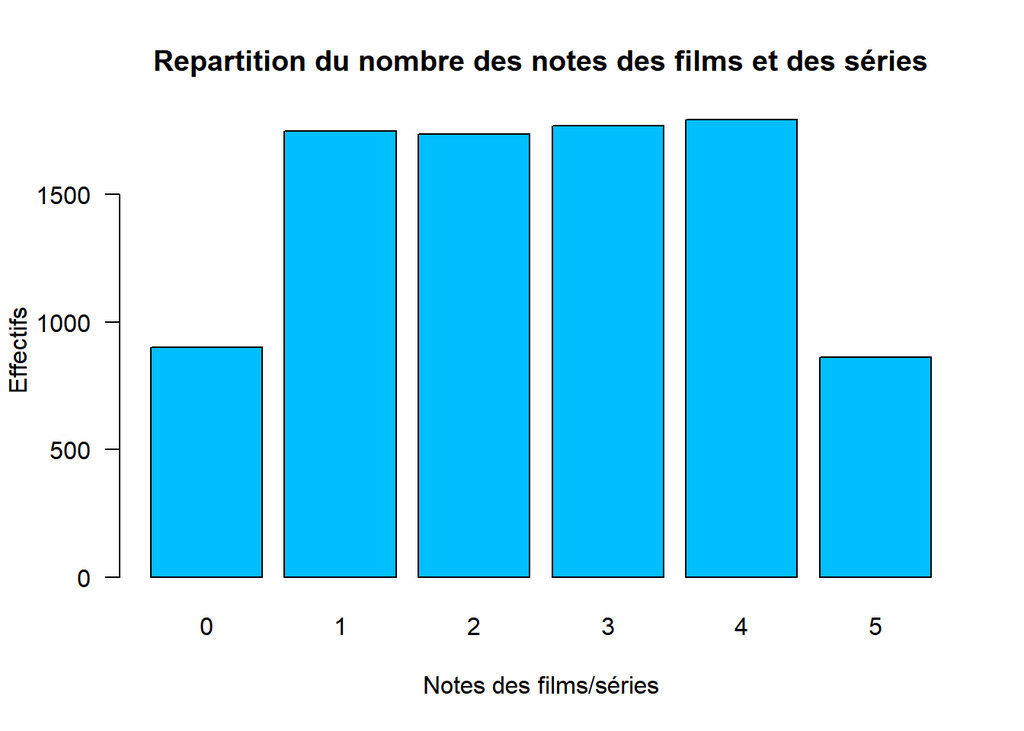

```r
tab <- table( x = films$marks )
barplot(height = tab, col="deepskyblue" ,
        main = "Repartition du nombre des notes des films et des séries", las= 1,
        xlab="Notes des films/séries", ylab="Effectifs")
```

Nous apercevons ici un graphique qui reprend les valeurs de notre trie à plat fait plus haut. On remarque que les notes les moins misent sont les extrêmes c’est-à-dire 0 et 5, on comprend donc que les personnes préfèrent mettre une note un peu moins prononcer car un film ne peut être rarement dans les extrêmes.

#Analyse Bivariées.

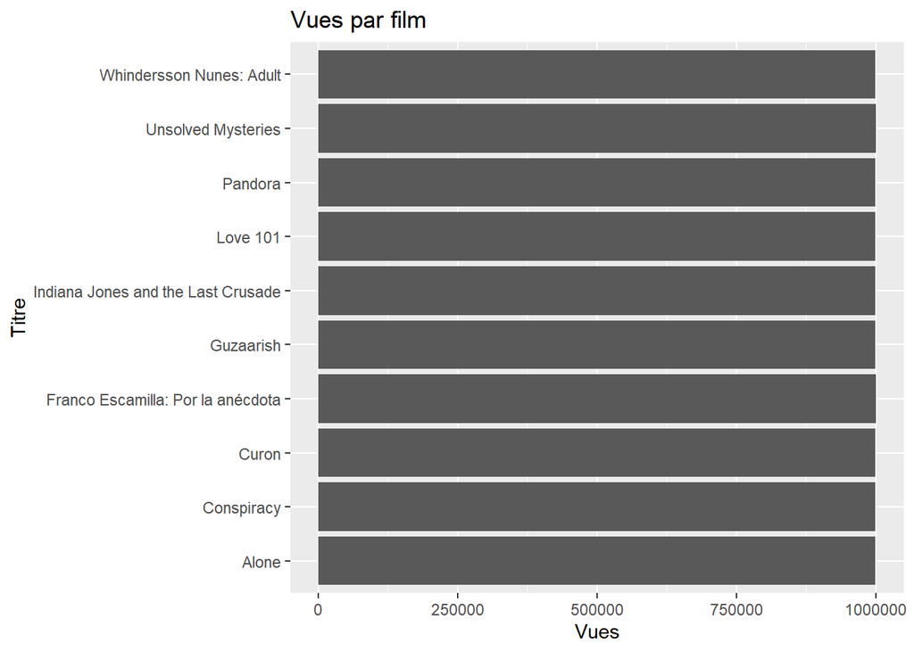

```r
b = films[order(films$view, decreasing = TRUE),]
filtre = b[c(1:10),]

ggplot(filtre, aes(x=title, y=view)) +
      geom_bar(stat = "identity") +
      coord_flip() + ggtitle("Vues par film") + labs(x = "Titre", y ="Vues")
```

Grâce à ce graphique on remarque de nombreux films atteind le million de vu. On constate aussi qu’aucun film les dépasse cela nous prouve que la base de donnée ne recueillit pas le nombreux de vu supérieur à un million.

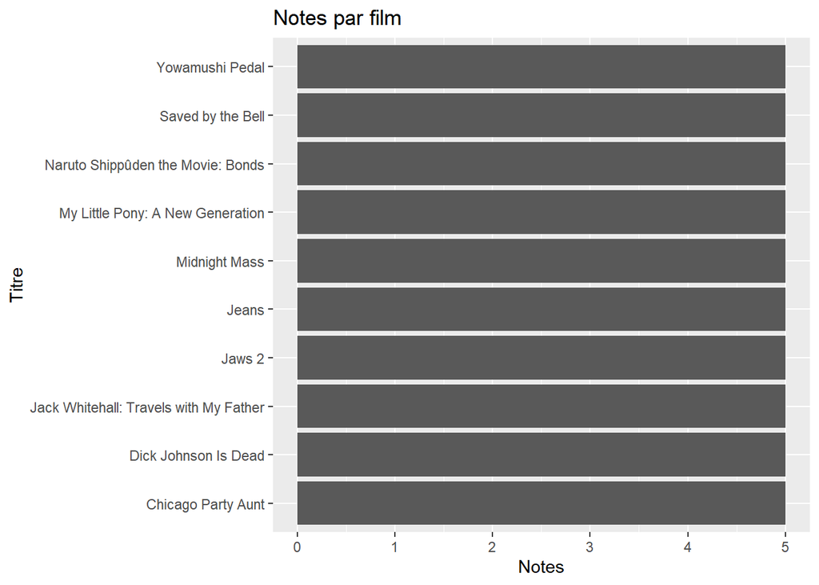

```r
b = films[order(films$marks, decreasing = TRUE),]
filtre = b[c(1:10),]

ggplot(filtre, aes(x=title, y=marks)) +
      geom_bar(stat = "identity") +
      coord_flip() + ggtitle("Notes par film") + labs(x = "Titre", y ="Notes")
```

Et enfin pour finir on remarque tout comme le graphique précédent qu’il y a beaucoup de films notés avec la note maximum qui est de 5. Il est donc compliqué d’y comparer avec les films les plus vus.